# Angular Momenta and Their Couplings

Author

Daniel Fischer

# Introduction

Angular momentum is one of the central structures of quantum mechanics and appears throughout atomic physics. Orbital angular momentum, electron spin, total electronic angular momentum, and nuclear spin all obey the same algebra, even though their physical origins can be quite different.

The aim of this chapter is therefore to develop the **general quantum-mechanical rules of angular momentum** before applying them to specific atomic systems. We begin with the commutation relations, use ladder operators as an algebraic tool to derive the allowed eigenvalues, and then discuss how two angular momenta are coupled.

Later chapters will specialize these results to orbital angular momentum and hydrogen wave functions, spin–orbit coupling, hyperfine structure, and spectroscopic transitions.

The specific goals for this chapter are:

1. Introduce the angular-momentum operators and their commutation relations.
2. Identify the observables that can be specified simultaneously for an angular-momentum state.
3. Use ladder operators to derive the allowed eigenvalues of $\hat j^2$ and $\hat j_z$ and the corresponding quantum numbers $j$ and $m$.
4. Determine the allowed values of the total angular momentum obtained by coupling two angular momenta.
5. Distinguish between coupled and uncoupled angular-momentum bases and introduce Clebsch–Gordan coefficients as the transformation between them.

**ImportantCore Knowledge — Know**

For any angular momentum operator $\hat{\vec j}=(\hat j_x,\hat j_y,\hat j_z)$,

$$[\hat j_i,\hat j_j]=i\hbar\,\epsilon_{ijk}\hat j_k,$$

or explicitly,

$$[\hat j_x,\hat j_y]=i\hbar\hat j_z,
\qquad
[\hat j_y,\hat j_z]=i\hbar\hat j_x,
\qquad
[\hat j_z,\hat j_x]=i\hbar\hat j_y.$$

With

$$\hat j^2=\hat j_x^2+\hat j_y^2+\hat j_z^2,$$

we have

$$[\hat j^2,\hat j_z]=0,$$

and the simultaneous eigenstates $|j,m_j\rangle$ satisfy

$$\boxed{\hat j^2|j,m_j\rangle=\hbar^2j(j+1)|j,m_j\rangle}$$

and

$$\boxed{\hat j_z|j,m_j\rangle=\hbar m_j|j,m_j\rangle}.$$

The allowed quantum numbers are

$$j=0,\frac12,1,\frac32,\ldots,
\qquad
m_j=-j,-j+1,\ldots,j,$$

so a given $j$ has $2j+1$ magnetic substates.

For two angular momenta,

$$\boxed{\hat{\vec J}=\hat{\vec j}_1+\hat{\vec j}_2},$$

with

$$\boxed{J=|j_1-j_2|,|j_1-j_2|+1,\ldots,j_1+j_2}$$

and

$$\boxed{M=m_1+m_2}.$$

Clebsch–Gordan coefficients connect the uncoupled basis $|j_1,m_1\rangle|j_2,m_2\rangle$ with the coupled basis $|j_1,j_2;J,M\rangle$.

**NoteWorking Knowledge — Understand**

You should understand that

- $\hat j^2$ and one component, conventionally $\hat j_z$, can be specified simultaneously, whereas different Cartesian components of angular momentum generally cannot;
- $j$ determines the magnitude of the angular momentum and $m_j$ its projection on the chosen quantization axis;
- general quantum-mechanical angular momentum allows integer and half-integer $j$, while orbital angular momentum will later be restricted to integer values by its spatial realization;
- when two angular momenta are coupled, the total $J$ can take all values from $|j_1-j_2|$ to $j_1+j_2$ in steps of one;
- the coupled and uncoupled bases describe the same physical state space, and Clebsch–Gordan coefficients are the change-of-basis coefficients between them.

The derivations using rotations and ladder operators are included below to show **where these results come from**, but the intermediate algebra is not intended as material to memorize.

# 1. Angular-Momentum Algebra

Quantum-mechanical angular momentum is represented by an operator vector

$$\hat{\vec j}=(\hat j_x,\hat j_y,\hat j_z).$$

Its defining algebra is

$$\boxed{[\hat j_i,\hat j_j]=i\hbar\epsilon_{ijk}\hat j_k}.$$

where the indices $i,j,k$ denote the Cartesian directions $x,y,z$, and $\epsilon_{ijk}$ is the **Levi-Civita symbol**. It is $+1$ for cyclic permutations of $(x,y,z)$, $-1$ for anticyclic permutations, and zero whenever two indices are the same. Thus, for example,

$$[\hat j_x,\hat j_y]=i\hbar\hat j_z,
\qquad
[\hat j_y,\hat j_z]=i\hbar\hat j_x,
\qquad
[\hat j_z,\hat j_x]=i\hbar\hat j_y.$$

Reversing the order changes the sign; for example,

$$[\hat j_y,\hat j_x]=-i\hbar\hat j_z.$$

These relations are universal: they apply to orbital angular momentum, spin, and any total angular momentum obtained by coupling individual angular momenta.

The commutation relations can be motivated in two complementary ways. The first starts from the position and momentum operators already introduced in wave mechanics and shows explicitly that orbital angular momentum obeys this algebra. The second is more general and shows why the same algebra follows from the geometry of rotations.

**NoteDerivation 1 — From position and momentum operators**

For orbital angular momentum,

$$\hat{\vec L}=\hat{\vec r}\times\hat{\vec p},$$

so that

$$\hat L_x=\hat y\hat p_z-\hat z\hat p_y,
\qquad
\hat L_y=\hat z\hat p_x-\hat x\hat p_z,
\qquad
\hat L_z=\hat x\hat p_y-\hat y\hat p_x.$$

The canonical commutation relation for position and momentum is

$$[\hat x_i,\hat p_j]=i\hbar\delta_{ij},$$

while different position components commute,

$$[\hat x_i,\hat x_j]=0,$$

and different momentum components commute,

$$[\hat p_i,\hat p_j]=0.$$

We now calculate $[\hat L_x,\hat L_y]$ explicitly:

$$\begin{aligned}
[\hat L_x,\hat L_y]
&=[\hat y\hat p_z-\hat z\hat p_y,\,
\hat z\hat p_x-\hat x\hat p_z]\\
&=[\hat y\hat p_z,\hat z\hat p_x]
-[\hat y\hat p_z,\hat x\hat p_z]
-[\hat z\hat p_y,\hat z\hat p_x]
+[\hat z\hat p_y,\hat x\hat p_z].
\end{aligned}$$

Consider the four terms separately.

For the first term, $\hat y$ commutes with $\hat z$, $\hat p_x$, and $\hat p_z$, while $[\hat p_z,\hat z]=-i\hbar$. Therefore,

$$\begin{aligned}
[\hat y\hat p_z,\hat z\hat p_x]
&=\hat y[\hat p_z,\hat z]\hat p_x\\
&=-i\hbar\,\hat y\hat p_x.
\end{aligned}$$

The second term vanishes because $\hat y$, $\hat x$, and $\hat p_z$ all commute with one another:

$$[\hat y\hat p_z,\hat x\hat p_z]=0.$$

The third term also vanishes:

$$[\hat z\hat p_y,\hat z\hat p_x]=0.$$

For the final term, $\hat p_y$ commutes with $\hat x$, $\hat z$, and $\hat p_z$, while $[\hat z,\hat p_z]=i\hbar$. Hence,

$$\begin{aligned}
[\hat z\hat p_y,\hat x\hat p_z]
&=\hat x[\hat z,\hat p_z]\hat p_y\\
&=i\hbar\,\hat x\hat p_y.
\end{aligned}$$

Putting the four terms together,

$$\begin{aligned}
[\hat L_x,\hat L_y]
&=i\hbar(\hat x\hat p_y-\hat y\hat p_x)\\
&=i\hbar\hat L_z.
\end{aligned}$$

The other two relations follow by cyclic permutation:

$$[\hat L_y,\hat L_z]=i\hbar\hat L_x,
\qquad
[\hat L_z,\hat L_x]=i\hbar\hat L_y.$$

Thus the familiar orbital definition $\hat{\vec L}=\hat{\vec r}\times\hat{\vec p}$ provides one concrete realization of the general angular-momentum algebra.

**NoteDerivation 2 — Angular momentum as the generator of rotations**

The previous derivation applies specifically to **orbital** angular momentum. There is a more general reason for the same commutator algebra: angular momentum generates rotations, and rotations about different axes do not commute.

## Infinitesimal rotations

A rotation by a small angle $d\theta$ about an axis $\hat{\vec n}$ is represented in quantum mechanics by

$$\hat U(\hat{\vec n},d\theta)
\simeq
1-\frac{i}{\hbar}d\theta\,\hat{\vec n}\cdot\hat{\vec j}.$$

For rotations about the Cartesian axes,

$$\hat U_x(\alpha)
\simeq 1-\frac{i\alpha}{\hbar}\hat j_x,
\qquad
\hat U_y(\beta)
\simeq 1-\frac{i\beta}{\hbar}\hat j_y.$$

The word **generator** means precisely that $\hat j_x$ determines the first-order change of a state under a rotation about $x$, $\hat j_y$ under a rotation about $y$, and so on.

## Why the order of rotations matters

For small classical rotations, the corresponding rotation matrices are

$$R_x(\alpha)\simeq
\begin{pmatrix}
1&0&0\\
0&1&-\alpha\\
0&\alpha&1
\end{pmatrix},$$

and

$$R_y(\beta)\simeq
\begin{pmatrix}
1&0&\beta\\
0&1&0\\
-\beta&0&1
\end{pmatrix}.$$

Multiply them in the two possible orders and retain terms through order $\alpha\beta$:

$$R_x(\alpha)R_y(\beta)
\simeq
\begin{pmatrix}
1&0&\beta\\
\alpha\beta&1&-\alpha\\
-\beta&\alpha&1
\end{pmatrix},$$

whereas

$$R_y(\beta)R_x(\alpha)
\simeq
\begin{pmatrix}
1&\alpha\beta&\beta\\
0&1&-\alpha\\
-\beta&\alpha&1
\end{pmatrix}.$$

Their difference is

$$R_xR_y-R_yR_x
\simeq
\alpha\beta
\begin{pmatrix}
0&-1&0\\
1&0&0\\
0&0&0
\end{pmatrix}.$$

But the matrix on the right is exactly the generator of an infinitesimal rotation about the $z$-axis. Indeed,

$$R_z(\gamma)
\simeq
\begin{pmatrix}
1&-\gamma&0\\
\gamma&1&0\\
0&0&1
\end{pmatrix}.$$

Thus changing the order of an infinitesimal $x$- and $y$-rotation produces, to lowest nonvanishing order, an additional rotation about $z$ of magnitude $\alpha\beta$.

A simple way to visualize this is to apply the two rotations to a vector initially pointing along $x$:

$$\vec v=(1,0,0).$$

Rotating first about $x$ and then about $y$ gives, to lowest order,

$$\vec v_A\simeq(1,0,-\beta),$$

while rotating first about $y$ and then about $x$ gives

$$\vec v_B\simeq(1,\alpha\beta,-\beta).$$

The difference,

$$\vec v_B-\vec v_A\simeq(0,\alpha\beta,0),$$

is exactly what a small positive $z$-rotation by angle $\alpha\beta$ does to a vector pointing along $x$.

## From the geometry to the quantum commutator

Now calculate the same difference using the quantum rotation operators:

$$\begin{aligned}
\hat U_x(\alpha)\hat U_y(\beta)
&\simeq
\left(1-\frac{i\alpha}{\hbar}\hat j_x\right)
\left(1-\frac{i\beta}{\hbar}\hat j_y\right),\\[4pt]
\hat U_y(\beta)\hat U_x(\alpha)
&\simeq
\left(1-\frac{i\beta}{\hbar}\hat j_y\right)
\left(1-\frac{i\alpha}{\hbar}\hat j_x\right).
\end{aligned}$$

Subtracting the two expressions, all first-order terms cancel and we obtain

$$\hat U_x\hat U_y-\hat U_y\hat U_x
\simeq
-\frac{\alpha\beta}{\hbar^2}
[\hat j_x,\hat j_y].$$

Geometrically, the same difference corresponds to an infinitesimal rotation about $z$ through angle $\alpha\beta$:

$$\hat U_z(\alpha\beta)-1
\simeq
-\frac{i\alpha\beta}{\hbar}\hat j_z.$$

Equating the two descriptions gives

$$-\frac{\alpha\beta}{\hbar^2}[\hat j_x,\hat j_y]
=
-\frac{i\alpha\beta}{\hbar}\hat j_z,$$

and therefore

$$\boxed{[\hat j_x,\hat j_y]=i\hbar\hat j_z}.$$

The cyclic relations follow in the same way:

$$[\hat j_y,\hat j_z]=i\hbar\hat j_x,
\qquad
[\hat j_z,\hat j_x]=i\hbar\hat j_y.$$

This argument is more general than the orbital derivation: it does not assume $\hat{\vec j}=\hat{\vec r}\times\hat{\vec p}$. This is why spin, which has no classical orbital coordinate, nevertheless obeys exactly the same angular-momentum algebra.

## 1.1 The operators $\hat j^2$ and $\hat j_z$

Define the squared angular-momentum operator as

$$\hat j^2=\hat j_x^2+\hat j_y^2+\hat j_z^2.$$

An important consequence of the angular-momentum commutation relations is that $\hat j^2$ commutes with each component of angular momentum. In particular,

$$[\hat j^2,\hat j_z]=0.$$

**NoteDerivation of $[\hat j^2,\hat j_z]=0$**

We begin by expanding the commutator:

$$\begin{aligned}
[\hat j^2,\hat j_z]
&=
[\hat j_x^2+\hat j_y^2+\hat j_z^2,\hat j_z] \\
&=
[\hat j_x^2,\hat j_z]
+
[\hat j_y^2,\hat j_z]
+
[\hat j_z^2,\hat j_z].
\end{aligned}$$

To evaluate the first two terms, we use the general identity

$$[\hat A\hat B,\hat C]
=
\hat A[\hat B,\hat C]
+
[\hat A,\hat C]\hat B.$$

For $\hat A=\hat B=\hat j_x$, this gives

$$[\hat j_x^2,\hat j_z]
=
\hat j_x[\hat j_x,\hat j_z]
+
[\hat j_x,\hat j_z]\hat j_x.$$

From the angular-momentum commutation relations,

$$[\hat j_z,\hat j_x]=i\hbar\hat j_y,$$

and therefore, reversing the order,

$$[\hat j_x,\hat j_z]=-i\hbar\hat j_y.$$

Substituting this into the previous expression gives

$$\begin{aligned}
[\hat j_x^2,\hat j_z]
&=
\hat j_x(-i\hbar\hat j_y)
+
(-i\hbar\hat j_y)\hat j_x\\
&=
-i\hbar
\left(
\hat j_x\hat j_y+\hat j_y\hat j_x
\right).
\end{aligned}$$

Now consider the second term:

$$[\hat j_y^2,\hat j_z]
=
\hat j_y[\hat j_y,\hat j_z]
+
[\hat j_y,\hat j_z]\hat j_y.$$

Here,

$$[\hat j_y,\hat j_z]=i\hbar\hat j_x,$$

so

$$\begin{aligned}
[\hat j_y^2,\hat j_z]
&=
\hat j_y(i\hbar\hat j_x)
+
(i\hbar\hat j_x)\hat j_y\\
&=
+i\hbar
\left(
\hat j_y\hat j_x+\hat j_x\hat j_y
\right).
\end{aligned}$$

These two contributions are equal in magnitude and opposite in sign:

$$[\hat j_x^2,\hat j_z]+[\hat j_y^2,\hat j_z]=0.$$

Finally,

$$[\hat j_z^2,\hat j_z]=0,$$

because any operator commutes with itself and with its own powers. Therefore,

$$\boxed{
[\hat j^2,\hat j_z]=0
}.$$

The same argument can be repeated for the other two components, giving

$$[\hat j^2,\hat j_x]
=
[\hat j^2,\hat j_y]
=
[\hat j^2,\hat j_z]
=
0.$$

Therefore $\hat j^2$ and $\hat j_z$ can be simultaneously diagonalized. We may choose states that are simultaneous eigenstates of both operators. At this stage, however, we have not yet determined their eigenvalues. That will follow from the algebra itself.

# 2. Ladder Operators and the Angular-Momentum Spectrum

Ladder operators are an algebraic tool that lets us derive the allowed angular-momentum eigenvalues directly from the commutation relations. They are useful here primarily because they provide the shortest route from the algebra to the spectrum, that is, the set of allowed eigenvalues of the angular-momentum operators.

## 2.1 Definition

Define

$$\hat j_+=\hat j_x+i\hat j_y,
\qquad
\hat j_-=\hat j_x-i\hat j_y.$$

They are adjoints of one another,

$$\hat j_+^\dagger=\hat j_-.$$

Using the angular-momentum commutation relations, one obtains

$$\boxed{[\hat j_z,\hat j_\pm]=\pm\hbar\hat j_\pm}$$

and

$$\boxed{[\hat j^2,\hat j_\pm]=0}.$$

The first relation will show that $\hat j_\pm$ changes the eigenvalue of $\hat j_z$, while the second shows that it does not change the eigenvalue of $\hat j^2$.

**NoteDerivation of the ladder-operator commutators**

Starting from

$$\hat j_\pm=\hat j_x\pm i\hat j_y,$$

we first calculate the commutator with $\hat j_z$. Using the linearity of the commutator,

$$[\hat A,\hat B+\hat C]
=
[\hat A,\hat B]+[\hat A,\hat C],$$

we find

$$\begin{aligned}
[\hat j_z,\hat j_\pm]
&=
[\hat j_z,\hat j_x\pm i\hat j_y]\\
&=
[\hat j_z,\hat j_x]
\pm i[\hat j_z,\hat j_y].
\end{aligned}$$

From the angular-momentum commutation relations,

$$[\hat j_z,\hat j_x]=i\hbar\hat j_y$$

and

$$[\hat j_z,\hat j_y]=-i\hbar\hat j_x.$$

Therefore,

$$\begin{aligned}
[\hat j_z,\hat j_\pm]
&=
i\hbar\hat j_y
\pm i(-i\hbar\hat j_x)\\
&=
i\hbar\hat j_y
\pm \hbar\hat j_x.
\end{aligned}$$

For the raising operator,

$$\begin{aligned}
[\hat j_z,\hat j_+]
&=
\hbar\hat j_x+i\hbar\hat j_y\\
&=
\hbar(\hat j_x+i\hat j_y)\\
&=
\hbar\hat j_+.
\end{aligned}$$

For the lowering operator,

$$\begin{aligned}
[\hat j_z,\hat j_-]
&=
-\hbar\hat j_x+i\hbar\hat j_y\\
&=
-\hbar(\hat j_x-i\hat j_y)\\
&=
-\hbar\hat j_-.
\end{aligned}$$

Thus,

$$\boxed{
[\hat j_z,\hat j_\pm]
=
\pm\hbar\hat j_\pm
}.$$

For the second commutator, recall from the previous section that the squared angular momentum commutes with every Cartesian component:

$$[\hat j^2,\hat j_x]
=
[\hat j^2,\hat j_y]
=
[\hat j^2,\hat j_z]
=
0.$$

Therefore,

$$\begin{aligned}
[\hat j^2,\hat j_\pm]
&=
[\hat j^2,\hat j_x\pm i\hat j_y]\\
&=
[\hat j^2,\hat j_x]
\pm i[\hat j^2,\hat j_y]\\
&=0.
\end{aligned}$$

Hence,

$$\boxed{
[\hat j^2,\hat j_\pm]=0
}.$$

## 2.2 Ladder action before knowing the spectrum

Let $|\lambda,m\rangle$ be a simultaneous normalized eigenstate of $\hat j^2$ and $\hat j_z$:

$$\hat j^2|\lambda,m\rangle=\lambda|\lambda,m\rangle,$$

$$\hat j_z|\lambda,m\rangle=\hbar m|\lambda,m\rangle.$$

We deliberately write the eigenvalue of $\hat j^2$ as the unknown quantity $\lambda$; the familiar form $\hbar^2j(j+1)$ has not yet been assumed.

From

$$[\hat j_z,\hat j_\pm]=\pm\hbar\hat j_\pm,$$

we obtain

$$\begin{aligned}
\hat j_z(\hat j_\pm|\lambda,m\rangle)
&=(\hat j_\pm\hat j_z+[\hat j_z,\hat j_\pm])|\lambda,m\rangle\\
&=\hbar(m\pm1)(\hat j_\pm|\lambda,m\rangle).
\end{aligned}$$

This has exactly the form of an eigenvalue equation for $\hat j_z$. Therefore, provided that $\hat j_\pm|\lambda,m\rangle$ is not zero, it is itself an eigenstate of $\hat j_z$ with eigenvalue $\hbar(m\pm1)$.

Thus $\hat j_+$ takes a state with quantum number $m$ into a state with quantum number $m+1$, while $\hat j_-$ takes it into a state with quantum number $m-1$:

$$m\longrightarrow m\pm1.$$

Because $[\hat j^2,\hat j_\pm]=0$, the value $\lambda$ is unchanged by this operation.

## 2.3 Why the ladder must terminate

The following identities are obtained directly from the definitions of $\hat j_\pm$:

$$\hat j_-\hat j_+
=\hat j^2-\hat j_z^2-\hbar\hat j_z,$$

$$\hat j_+\hat j_-
=\hat j^2-\hat j_z^2+\hbar\hat j_z.$$

Now consider the norm of a raised state:

$$\begin{aligned}
\|\hat j_+|\lambda,m\rangle\|^2
&=\langle\lambda,m|\hat j_-\hat j_+|\lambda,m\rangle\\
&=\lambda-\hbar^2m(m+1).
\end{aligned}$$

Similarly,

$$\|\hat j_-|\lambda,m\rangle\|^2
=\lambda-\hbar^2m(m-1).$$

A norm cannot be negative. Therefore the ladder cannot continue indefinitely in either direction. There must be a highest state, with magnetic quantum number $m_{\max}$, satisfying

$$\hat j_+|\lambda,m_{\max}\rangle=0.$$

For this state,

$$\lambda-\hbar^2m_{\max}(m_{\max}+1)=0,$$

so

$$\lambda=\hbar^2m_{\max}(m_{\max}+1).$$

Likewise there must be a lowest state, with $m_{\min}$, satisfying

$$\hat j_-|\lambda,m_{\min}\rangle=0,$$

which gives

$$\lambda=\hbar^2m_{\min}(m_{\min}-1).$$

Equating the two expressions for $\lambda$,

$$m_{\max}(m_{\max}+1)
=m_{\min}(m_{\min}-1).$$

This can be written as

$$(m_{\max}+m_{\min})(m_{\max}-m_{\min}+1)=0.$$

Since the second factor is positive for a nontrivial ladder,

$$m_{\min}=-m_{\max}.$$

We define

$$j\equiv m_{\max}.$$

Hence

$$m=-j,-j+1,\ldots,j-1,j.$$

Because the ladder advances in integer steps, the distance from $-j$ to $+j$ must be an integer:

$$2j=0,1,2,3,\ldots$$

and therefore

$$\boxed{j=0,\frac12,1,\frac32,2,\ldots}.$$

Finally, using $m_{\max}=j$ in the expression for $\lambda$ gives

$$\boxed{\lambda=\hbar^2j(j+1)}.$$

Thus the characteristic angular-momentum eigenvalues follow from the commutation relations and the requirement that quantum-state norms be nonnegative.

**NoteOptional detail — Normalized action of the ladder operators**

Once the spectrum has been derived, write

$$\hat j_\pm|j,m\rangle=C_\pm(j,m)|j,m\pm1\rangle.$$

Using

$$\|\hat j_+|j,m\rangle\|^2
=\hbar^2[j(j+1)-m(m+1)]$$

and

$$\|\hat j_-|j,m\rangle\|^2
=\hbar^2[j(j+1)-m(m-1)],$$

one obtains, with the conventional phase choice,

$$\boxed{
\hat j_\pm|j,m\rangle
=\hbar\sqrt{j(j+1)-m(m\pm1)}\,|j,m\pm1\rangle.
}$$

This coefficient is useful in explicit calculations, but it is not necessary to memorize for the purposes of this course.

# 3. Eigenvalue Relations and Physical Interpretation

The ladder-operator argument in the previous section led directly to the allowed angular-momentum eigenvalues. We can therefore summarize the result in the form that will be used throughout the rest of the course:

$$\boxed{
\hat j^2|j,m_j\rangle
=\hbar^2j(j+1)|j,m_j\rangle
}$$

and

$$\boxed{
\hat j_z|j,m_j\rangle
=\hbar m_j|j,m_j\rangle.
}$$

These two equations have a simple physical interpretation:

- $\hat j^2$ determines the **magnitude** of the angular momentum;
- $\hat j_z$ determines its **projection along a chosen axis**, and therefore gives information about its orientation relative to that axis.

## 3.1 Magnitude of the angular momentum

For a state with angular-momentum quantum number $j$, the operator $\hat j^2$ has the eigenvalue

$$\hbar^2 j(j+1).$$

Since $\hat j^2$ represents the squared magnitude of the angular momentum, the corresponding magnitude is

$$\boxed{
|\vec j|=\hbar\sqrt{j(j+1)}.
}$$

Thus the quantum number $j$ determines the **length of the angular-momentum vector** in the usual vector-model representation.

The allowed values are

$$j=0,\frac12,1,\frac32,\ldots.$$

## 3.2 Projection and orientation

The second eigenvalue equation,

$$\hat j_z|j,m_j\rangle
=
\hbar m_j|j,m_j\rangle,$$

gives the projection of the angular momentum onto the $z$-axis:

$$\boxed{
j_z=\hbar m_j.
}$$

For a given $j$, the allowed projection quantum numbers are

$$m_j=-j,-j+1,\ldots,j,$$

so there are

$$2j+1$$

possible projections.

The projection tells us about the **orientation of the angular momentum relative to the chosen axis**. In the vector model, if $\theta$ is the angle between $\vec j$ and the $z$-axis,

$$j_z=|\vec j|\cos\theta,$$

and therefore

$$\boxed{
\cos\theta=
\frac{m_j}{\sqrt{j(j+1)}}.
}$$

Thus a fixed value of $j$ fixes the length of the angular momentum, while the different allowed values of $m_j$ correspond to different allowed projections, or orientations relative to the chosen axis.

## 3.3 Why do we use the $z$-axis?

There is nothing fundamentally special about the $z$-axis. In fact,

$$[\hat j^2,\hat j_x]
=
[\hat j^2,\hat j_y]
=
[\hat j^2,\hat j_z]
=
0,$$

so we could choose any one component together with $\hat j^2$.

The reason for conventionally choosing $\hat j_z$ is simply that we must choose **one reference direction**, called the **quantization axis**, and the $z$-axis is the standard choice.

In a physical problem, the quantization axis is often chosen to coincide with a preferred direction, for example an external magnetic field or a symmetry axis.

What we cannot do is specify all three components simultaneously, because

$$[\hat j_x,\hat j_y]\neq0,
\qquad
[\hat j_y,\hat j_z]\neq0,
\qquad
[\hat j_z,\hat j_x]\neq0.$$

A state $|j,m_j\rangle$ therefore has a definite magnitude and a definite projection along the chosen quantization axis, but not a definite classical direction in three-dimensional space.

The vector model in Figure 1 illustrates this for $j=3$. All seven states have the same angular-momentum magnitude,

$$|\vec j|=\hbar\sqrt{3(3+1)}=\hbar\sqrt{12},$$

but their projections on the $z$-axis take the seven values

$$m_j\hbar=-3\hbar,-2\hbar,\ldots,+3\hbar.$$

Each allowed projection therefore corresponds to a different angle with respect to the $z$-axis. Because the transverse components are not simultaneously defined, the figure represents each orientation as a cone around the $z$-axis rather than as a uniquely specified classical direction.

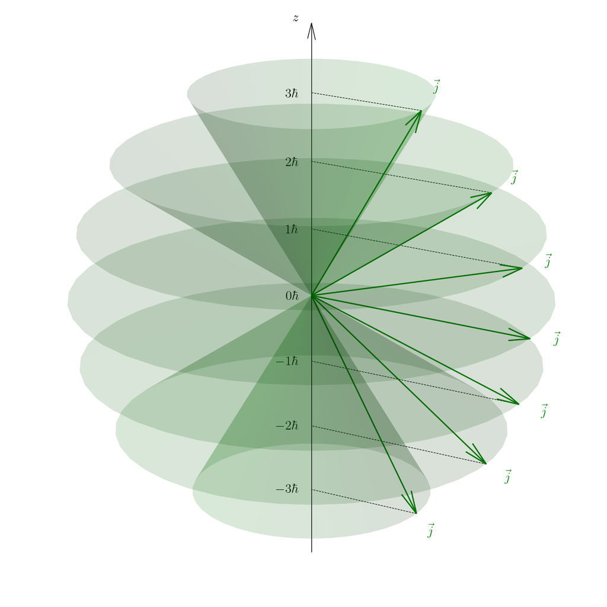

Figure 1: Vector-model representation for $j=3$. The magnitude of the angular momentum is fixed, while the seven possible values $m_j=-3,\ldots,3$ give different projections on the chosen $z$-axis. Each projection corresponds to a cone of possible directions around the quantization axis.

```python
import numpy as np
import matplotlib.pyplot as plt
from scipy.spatial.transform import Rotation as R

plt.rcParams['text.usetex'] = True
plt.rcParams['font.family'] = 'serif'
plt.rcParams['font.size'] = 15

j = 3
m_arr = np.arange(-j, j + 1, 1)
J0 = np.array([0, 0, np.sqrt(j * (j + 1))])

def r_euler(jvec, m):
    if np.abs(m) <= j and np.linalg.norm(jvec) != 0:
        return R.from_euler(
            'xyz',
            [0, -np.arccos(m/np.linalg.norm(jvec))*180/np.pi, 0],
            degrees=True
        ).apply(jvec)
    return np.array([0, 0, 0])

def unit(v):
    norm = np.linalg.norm(v)
    if norm < 1e-10:
        return np.zeros_like(v)
    return v / norm

fig = plt.figure(figsize=(8, 8))
ax = fig.add_subplot(111, projection="3d")

def draw_vector(r, v, color, label):
    ax.quiver(
        r[0], r[1], r[2], v[0], v[1], v[2],
        color=color, lw=1.2, arrow_length_ratio=0.1
    )
    ax.text(
        r[0]+v[0]*1.1,
        r[1]+v[1]*1.1,
        r[2]+v[2]*1.1,
        label,
        color=color,
        fontsize=12
    )

ax.quiver(0, 0, -4, 0, 0, 8, color='k', lw=.6, arrow_length_ratio=0.03)
ax.text(0.2, 0, 4, s=r'$z$', ha='right', color='k', fontsize=12)

def plot_cone(axis, angle, height, color, alpha=0.3, resolution=40):
    axis = unit(axis)
    theta = np.linspace(0, 2 * np.pi, resolution)
    z = np.linspace(0, height, resolution)
    theta, z = np.meshgrid(theta, z)
    r = z * np.tan(angle)
    x = r * np.cos(theta)
    y = r * np.sin(theta)

    def rotation_matrix(u):
        u = unit(u)
        zhat = np.array([0, 0, 1])
        v = np.cross(zhat, u)
        c = np.dot(zhat, u)
        if np.linalg.norm(v) < 1e-10:
            if c < 0:
                return np.diag([1, -1, -1])
            return np.eye(3)
        vx = np.array([
            [0, -v[2], v[1]],
            [v[2], 0, -v[0]],
            [-v[1], v[0], 0]
        ])
        return np.eye(3) + vx + vx @ vx * (1 / (1 + c))

    R_mat = rotation_matrix(axis)
    xyz = R_mat @ np.vstack([x.flatten(), y.flatten(), z.flatten()])
    x_rot = xyz[0].reshape(x.shape)
    y_rot = xyz[1].reshape(y.shape)
    z_rot = xyz[2].reshape(z.shape)
    ax.plot_surface(
        x_rot, y_rot, z_rot,
        color=color, alpha=alpha, linewidth=0, shade=True
    )

def plot_disk(axis, radius, color, alpha=0.3, resolution=40):
    phi = np.linspace(0, 2 * np.pi, resolution)
    r = np.linspace(0, radius, resolution)
    phi, r = np.meshgrid(phi, r)
    x = r * np.cos(phi)
    y = r * np.sin(phi)
    z = np.zeros_like(x)
    ax.plot_surface(x, y, z, color=color, alpha=alpha, linewidth=0, shade=True)

for m in m_arr:
    J = r_euler(J0, m)
    draw_vector(np.zeros(3), J, "green", r"$\vec{j}$")
    ax.plot([J[0], 0], [J[1], 0], [J[2], J[2]], linewidth=0.5, linestyle='--', color='k')
    ax.text(0.2, 0, J[2]-0.1, s=f'${m} \\hbar$', ha='right', color='k', fontsize=12)
    angle_Jz = np.arccos(J[2] / np.linalg.norm(J))
    if m == 0:
        plot_disk([0, 0, 1], np.linalg.norm(J), "green", alpha=0.15)
    else:
        plot_cone([0, 0, 1], angle_Jz, m, "green", alpha=0.15)

max_extent = 2.5
ax.set_xlim([-max_extent, max_extent])
ax.set_ylim([-max_extent, max_extent])
ax.set_zlim([-max_extent, max_extent])
ax.set_xlabel('x')
ax.set_ylabel('y')
ax.set_zlabel('z')
ax.grid(False)
ax.set_axis_off()
ax.set_box_aspect([1, 1, 1])
ax.view_init(elev=20, azim=120)
plt.tight_layout()
plt.show()
```

# 4. Coupling of Angular Momenta

So far we have considered a single angular momentum. Atomic systems, however, often contain several angular momenta at the same time. Examples are the orbital and spin angular momenta of an electron, or the electronic and nuclear angular momenta of an atom.

When two angular momenta interact, we say that they are **coupled**. Physically, the interaction can transfer angular momentum between the two subsystems. Their individual orientations may therefore change, even when the angular momentum of the complete system remains constant.

We define the **total angular momentum**

$$\boxed{
\hat{\vec J}
=
\hat{\vec j}_1+\hat{\vec j}_2
}.$$

The central idea is that, for an isolated system with a rotationally invariant Hamiltonian, this total angular momentum is conserved. This conservation law also tells us which quantum numbers provide the most natural description of the coupled system.

## 4.1 Coupling and Angular-Momentum Conservation

In quantum mechanics, conservation of an observable is expressed by the corresponding operator commuting with the Hamiltonian. For a rotationally invariant Hamiltonian,

$$[\hat H,\hat J^2]=0$$

and, after choosing a quantization axis,

$$[\hat H,\hat J_z]=0.$$

The quantum numbers $J$ and $M$ can therefore be used to label stationary states of the complete system.

At the same time, the individual angular momenta need not be conserved separately. A familiar example from atomic physics is **spin–orbit coupling**,

$$\hat H_{\mathrm{SO}}
\propto
\hat{\vec L}\cdot\hat{\vec S}.$$

Because this interaction depends on the relative orientation of $\vec L$ and $\vec S$, the separate projections do not commute with the spin–orbit Hamiltonian:

$$[\hat H_{\mathrm{SO}},\hat L_z]\neq0,
\qquad
[\hat H_{\mathrm{SO}},\hat S_z]\neq0.$$

Consequently, $m_L$ and $m_S$ are not, in general, conserved quantum numbers in the presence of spin–orbit coupling.

However, with

$$\hat{\vec J}
=
\hat{\vec L}+\hat{\vec S},$$

we have

$$\begin{aligned}
{}[\hat H_{\mathrm{SO}},\hat J_z]
&=
[\hat H_{\mathrm{SO}},\hat L_z+\hat S_z]\\
&=
[\hat H_{\mathrm{SO}},\hat L_z]
+
[\hat H_{\mathrm{SO}},\hat S_z]\\
&=0.
\end{aligned}$$

The changes in the orbital and spin projections therefore compensate each other: angular momentum can be exchanged between $\vec L$ and $\vec S$, while their total projection remains constant.

Likewise,

$$[\hat H_{\mathrm{SO}},\hat J^2]=0.$$

Thus $J$ and $M$ are conserved quantum numbers for the spin–orbit Hamiltonian, whereas $m_L$ and $m_S$ separately are not.

This gives the physical reason for introducing the **coupled basis**. Instead of describing the state by the separate projections,

$$|L,m_L\rangle|S,m_S\rangle,$$

we use states of definite total angular momentum,

$$|L,S;J,M\rangle.$$

The connection becomes particularly clear from

$$\begin{aligned}
\hat J^2
&=
(\hat{\vec L}+\hat{\vec S})^2\\
&=
\hat L^2+\hat S^2
+
2\hat{\vec L}\cdot\hat{\vec S},
\end{aligned}$$

or

$$\boxed{
\hat{\vec L}\cdot\hat{\vec S}
=
\frac12
\left(
\hat J^2-\hat L^2-\hat S^2
\right).
}$$

A state $|L,S;J,M\rangle$ is an eigenstate of $\hat L^2$, $\hat S^2$, and $\hat J^2$. The spin–orbit interaction is therefore diagonal in this basis.

More generally, the most useful basis is usually the one built from operators that commute with the Hamiltonian. Which angular momenta should be coupled therefore depends on the interactions present in the physical system.

## 4.2 Why does the total angular momentum obey the same algebra?

The components of the two different angular momenta act on different degrees of freedom and therefore commute with one another,

$$[\hat j_{1i},\hat j_{2j}]=0.$$

With

$$\hat J_i=\hat j_{1i}+\hat j_{2i},$$

we therefore obtain

$$\begin{aligned}
{}[\hat J_x,\hat J_y]
&=
[\hat j_{1x}+\hat j_{2x},
\hat j_{1y}+\hat j_{2y}]\\
&=
[\hat j_{1x},\hat j_{1y}]
+
[\hat j_{2x},\hat j_{2y}]\\
&=
i\hbar\hat j_{1z}
+
i\hbar\hat j_{2z}\\
&=
i\hbar\hat J_z.
\end{aligned}$$

Thus the total angular momentum obeys exactly the same angular-momentum algebra as each individual angular momentum.

Its eigenstates can therefore be labeled by quantum numbers $J$ and $M$,

$$\hat J^2|J,M\rangle
=
\hbar^2J(J+1)|J,M\rangle,$$

and

$$\hat J_z|J,M\rangle
=
\hbar M|J,M\rangle.$$

## 4.3 Uncoupled and coupled bases

There are two equivalent ways of describing the same combined system.

### Uncoupled basis

If we describe the two angular momenta separately, we use states

$$|j_1,m_1\rangle|j_2,m_2\rangle.$$

These are simultaneous eigenstates of

$$\hat j_1^2,\qquad
\hat j_{1z},\qquad
\hat j_2^2,\qquad
\hat j_{2z}.$$

The total projection is simply

$$\boxed{
M=m_1+m_2
}.$$

This is called the **uncoupled basis** because the two angular momenta are labeled separately.

### Coupled basis

Alternatively, we can describe the same states in terms of the total angular momentum,

$$|j_1,j_2;J,M\rangle.$$

These are simultaneous eigenstates of

$$\hat j_1^2,\qquad
\hat j_2^2,\qquad
\hat J^2,\qquad
\hat J_z.$$

This is called the **coupled basis**.

The two bases contain exactly the same physical states. They are simply different choices of basis.

## 4.4 Which basis should we use?

The appropriate basis is usually the one whose quantum numbers correspond to operators that commute with the Hamiltonian.

If the Hamiltonian is naturally diagonal in the individual projections $m_1$ and $m_2$—for example when an external-field interaction dominates over the coupling between the two angular momenta—the uncoupled basis

$$|j_1,m_1\rangle|j_2,m_2\rangle$$

is convenient.

If the interaction couples the two angular momenta and $\hat J^2$ and $\hat J_z$ are conserved, the coupled basis

$$|j_1,j_2;J,M\rangle$$

is the natural choice, as illustrated by the spin–orbit interaction in Section 4.1.

The two descriptions are not different physical theories; they are different bases for the same Hilbert space, chosen to suit the Hamiltonian of the problem.

## 4.5 Allowed values of the total angular momentum

For two angular momenta with quantum numbers $j_1$ and $j_2$, the allowed values of the total angular-momentum quantum number are

$$\boxed{
J=
|j_1-j_2|,
|j_1-j_2|+1,
\ldots,
j_1+j_2
}.$$

Thus the largest possible total angular momentum is

$$J_{\max}=j_1+j_2,$$

while the smallest is

$$J_{\min}=|j_1-j_2|.$$

For example, if

$$j_1=1,
\qquad
j_2=\frac12,$$

then

$$J=\frac32,\frac12.$$

**NoteWhy are the allowed values $J=|j_1-j_2|,\ldots,j_1+j_2$?**

The result can be understood directly from the allowed projection quantum numbers.

For the two separate angular momenta,

$$m_1=-j_1,\ldots,j_1$$

and

$$m_2=-j_2,\ldots,j_2.$$

The total projection is

$$M=m_1+m_2.$$

The largest possible value of $M$ occurs when both angular momenta have their largest projections:

$$m_1=j_1,
\qquad
m_2=j_2.$$

Therefore,

$$M_{\max}=j_1+j_2.$$

But for an angular-momentum multiplet with quantum number $J$, the largest projection is always

$$M_{\max}=J.$$

Consequently, the combined system must contain a multiplet with

$$\boxed{
J_{\max}=j_1+j_2.
}$$

Now consider the next smaller value,

$$M=j_1+j_2-1.$$

There are generally two uncoupled states with this value of $M$:

$$|j_1,j_1-1\rangle|j_2,j_2\rangle$$

and

$$|j_1,j_1\rangle|j_2,j_2-1\rangle.$$

One particular linear combination belongs to the $J=j_1+j_2$ multiplet: it is obtained by applying the total lowering operator

$$\hat J_-=\hat j_{1-}+\hat j_{2-}$$

to the state with maximum $M$.

The other independent combination must therefore begin a new multiplet whose highest projection is

$$M=J=j_1+j_2-1.$$

Thus a multiplet with

$$J=j_1+j_2-1$$

also occurs.

The same argument can be repeated. As $M$ is lowered, new independent multiplets appear with

$$J=j_1+j_2,\;
j_1+j_2-1,\;
j_1+j_2-2,\ldots$$

until the smaller angular momentum has been completely opposed to the larger one.

Assume, for example, that $j_1\ge j_2$. The smallest possible total angular momentum is then reached when the two angular momenta are as opposed as possible:

$$J_{\min}=j_1-j_2.$$

If instead $j_2>j_1$, the result is $j_2-j_1$. Combining both cases gives

$$\boxed{
J_{\min}=|j_1-j_2|.
}$$

Therefore,

$$\boxed{
J=
|j_1-j_2|,
|j_1-j_2|+1,
\ldots,
j_1+j_2.
}$$

As a check, the total number of states must be the same in the coupled and uncoupled descriptions.

The uncoupled basis contains

$$(2j_1+1)(2j_2+1)$$

states.

Assuming $j_1\ge j_2$, the coupled basis contains

$$\sum_{J=j_1-j_2}^{j_1+j_2}(2J+1)$$

states.

Evaluating the sum gives

$$\sum_{J=j_1-j_2}^{j_1+j_2}(2J+1)
=
(2j_1+1)(2j_2+1),$$

so the allowed $J$ multiplets account for all states of the combined system.

## 4.6 Physical examples

| Coupling | Typical physical context | Example |
| --- | --- | --- |
| $\vec L+\vec S=\vec J$ | Fine structure | orbital and electron-spin angular momentum |
| $\vec J+\vec I=\vec F$ | Hyperfine structure | electronic and nuclear angular momentum |
| $\vec j_1+\vec j_2$ | Multi-electron atoms | coupling of individual electron angular momenta |

The mathematical rules are the same in each case; only the physical meaning of the individual angular momenta changes.

# 5. Clebsch–Gordan Coefficients

The uncoupled and coupled bases are related by a change of basis:

$$\boxed{
|j_1,j_2;J,M\rangle
=
\sum_{m_1,m_2}
C^{J,M}_{j_1,m_1;j_2,m_2}
|j_1,j_2;m_1,m_2\rangle.
}$$

The coefficients $C^{J,M}_{j_1,m_1;j_2,m_2}$ are the **Clebsch–Gordan coefficients**.

Only terms satisfying

$$M=m_1+m_2$$

can contribute. The allowed $J$ values must also satisfy

$$|j_1-j_2|\le J\le j_1+j_2.$$

The coefficients are normalized so that the coupled states are normalized. In practice they are taken from tables or calculated using symbolic or numerical software; they are not normally memorized.

## 5.1 Example: $j_1=1$ and $j_2=\tfrac12$

For $J=\tfrac32$, the state with maximum projection is unique:

$$\left|\frac32,\frac32\right\rangle
=
|1,1\rangle
\left|\frac12,\frac12\right\rangle.$$

For $M=\tfrac12$, two uncoupled states are possible, so a coupled state is a superposition:

$$\left|\frac32,\frac12\right\rangle
=
\sqrt{\frac23}
|1,0\rangle
\left|\frac12,\frac12\right\rangle
+
\sqrt{\frac13}
|1,1\rangle
\left|\frac12,-\frac12\right\rangle.$$

The orthogonal combination belongs to the $J=\tfrac12$ manifold:

$$\left|\frac12,\frac12\right\rangle
=
\sqrt{\frac13}
|1,0\rangle
\left|\frac12,\frac12\right\rangle
-
\sqrt{\frac23}
|1,1\rangle
\left|\frac12,-\frac12\right\rangle.$$

This example illustrates what the Clebsch–Gordan coefficients do: they specify the amplitudes with which different $(m_1,m_2)$ product states combine into states of definite total $J$ and $M$.

**NoteAdditional detail — Orthogonality, completeness, and Wigner 3-j symbols**

Because the transformation between coupled and uncoupled bases is unitary, the Clebsch–Gordan coefficients obey orthogonality relations such as

$$\sum_{m_1,m_2}
C^{J,M}_{j_1,m_1;j_2,m_2}
C^{J',M'}_{j_1,m_1;j_2,m_2}
=
\delta_{J,J'}\delta_{M,M'}.$$

They can also be written in terms of Wigner $3j$ symbols:

$$C^{J,M}_{j_1,m_1;j_2,m_2}
=
(-1)^{j_1-j_2+M}\sqrt{2J+1}
\begin{pmatrix}
j_1 & j_2 & J\\
m_1 & m_2 & -M
\end{pmatrix}.$$

These relations are useful in more advanced angular-momentum calculations but are not part of the core knowledge expected here.

# Summary

The central results of this chapter are the angular-momentum eigenvalue relations and the rules for coupling angular momenta. The commutation relations determine the algebra, ladder operators provide a convenient derivation of the allowed spectrum, and Clebsch–Gordan coefficients connect uncoupled and coupled descriptions of composite angular-momentum systems.

The same framework will be used repeatedly in later chapters for orbital angular momentum, electron spin, fine structure, hyperfine structure, and atomic spectroscopy.